# Repeated Measures and Longitudinal Data (ELMR Chapter 11)

Biostat 200C

Author

Dr. Jin Zhou @ UCLA

Published

May 14, 2026

Display system information and load `tidyverse` and `faraway` packages

```r
library(tidyverse)
library(faraway)
library(precrec)
# install.packages("precrec")
```

## 1 Additional reading materials

- Applied longitudinal analysis / Garrett M. Fitzmaurice, Nan M. Laird, James H. Ware.
- [Analysis of longitudinal data](https://search.library.ucla.edu/permalink/01UCS_LAL/17p22dp/alma9912401060406531)

## 2 Longitudinal data - PSID data set

- `psid` (Panel Study of Income Dynamics) data records the income of 85 individuals, who were aged 25-39 in 1968 and had complete data for at least 11 of the years between 1968 and 1990.

```r
psid <- as_tibble(psid) %>%
  print(n = 30)
```

```
# A tibble: 1,661 × 6
     age  educ sex   income  year person
   <int> <int> <fct>  <int> <int>  <int>
 1    31    12 M       6000    68      1
 2    31    12 M       5300    69      1
 3    31    12 M       5200    70      1
 4    31    12 M       6900    71      1
 5    31    12 M       7500    72      1
 6    31    12 M       8000    73      1
 7    31    12 M       8000    74      1
 8    31    12 M       9600    75      1
 9    31    12 M       9000    76      1
10    31    12 M       9000    77      1
11    31    12 M      23000    78      1
12    31    12 M      22000    79      1
```

[output cut: 19 more lines]

```r
summary(psid)
```

```
      age             educ       sex         income            year
 Min.   :25.00   Min.   : 3.00   F:732   Min.   :     3   Min.   :68.00
 1st Qu.:28.00   1st Qu.:10.00   M:929   1st Qu.:  4300   1st Qu.:73.00
 Median :34.00   Median :12.00           Median :  9000   Median :78.00
 Mean   :32.19   Mean   :11.84           Mean   : 13575   Mean   :78.61
 3rd Qu.:36.00   3rd Qu.:13.00           3rd Qu.: 18050   3rd Qu.:84.00
 Max.   :39.00   Max.   :16.00           Max.   :180000   Max.   :90.00
     person
 Min.   : 1.00
 1st Qu.:20.00
 Median :42.00
 Mean   :42.44
 3rd Qu.:63.00
 Max.   :85.00
```

- Display trajectories of first 20 individuals.

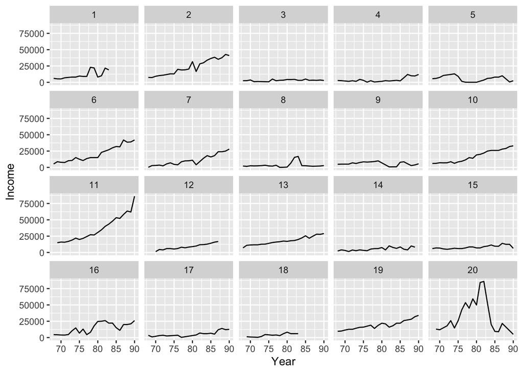

```r
psid %>%
  filter(person <= 20) %>%
  ggplot() +
  geom_line(mapping = aes(x = year, y = income)) +
  facet_wrap(~ person) +
  labs(x = "Year", y = "Income")
```

- Income trajectories stratified by sex. We observe men’s incomes are generally higher and less variable than women’s. Women’s income seems to increase quicker than men’s. How to test these hypotheses?

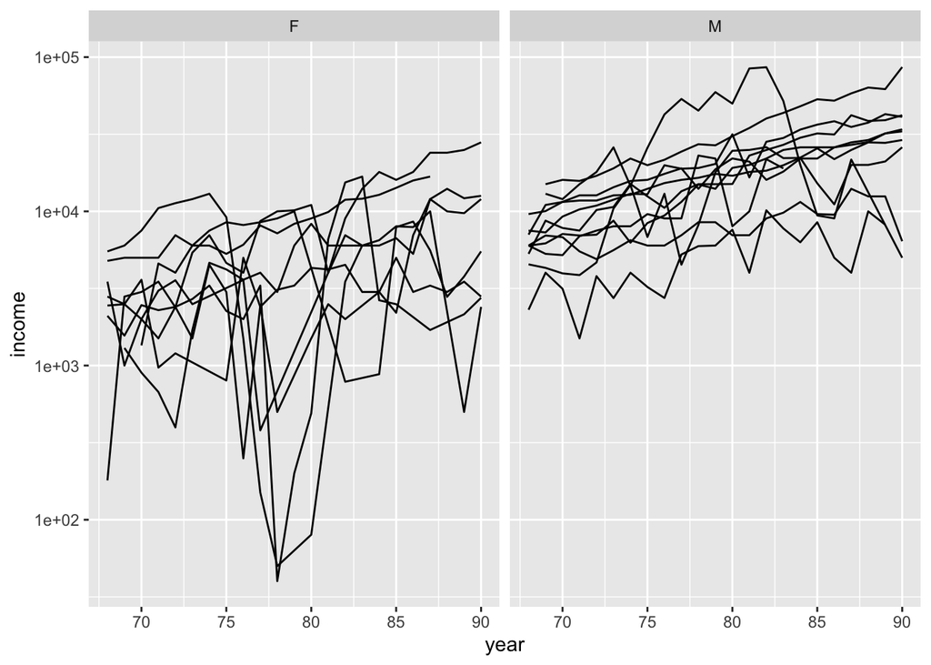

```r
psid %>%
  filter(person <= 20) %>%
  ggplot() +
  geom_line(mapping = aes(x = year, y = income, group = person)) +
  facet_wrap(~ sex) +
  scale_y_log10()
```

- If we fit a seperate linear model for each individual, we see variability in the intercepts and slopes. We use log income as response and center `year` by the median 78.

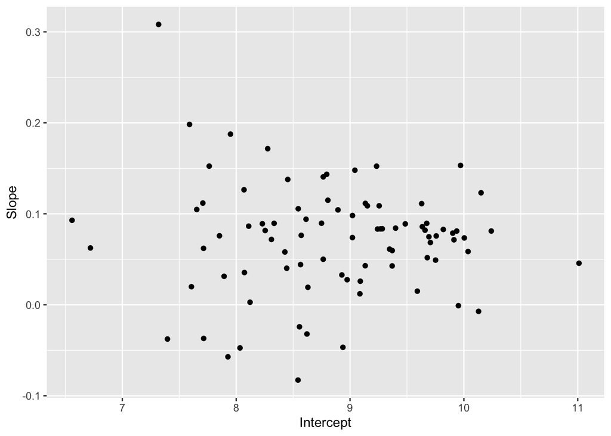

```r
library(lme4)

psid <- psid %>%
  mutate(cyear = I(year - 78))

oldw <- getOption("warn")
options(warn = -1) # turn off warnings
ml <- lmList(log(income) ~ cyear | person, data = psid)
options(warn = oldw)

intercepts <- sapply(ml, coef)[1, ]
slopes     <- sapply(ml, coef)[2, ]
tibble(int = intercepts,
       slo = slopes) %>%
  ggplot() +
  geom_point(mapping = aes(x = int, y = slo)) +
  labs(x = "Intercept", y = "Slope")
```

- We consider a linear mixed model with random intercepts and random slopes
  $$\log (\text{income}_{ij}) = \mu + \text{year}_i \cdot \beta_{\text{year}} + \text{sex}_j \cdot \beta_{\text{sex}} + (\text{sex}_j \times \text{year}_i) \cdot \beta_{\text{sex} \times \text{year}} + \text{educ}_j \times \beta_{\text{educ}} + \text{age}_j \cdot \beta_{\text{age}} + \gamma_{0,j} + \text{year}_i \cdot \gamma_{1,j} + \epsilon_{ij}$$
  where $i$ indexes year and $j$ indexes individual. The random intercepts and slopes are iid
  $$\begin{pmatrix}
  \gamma_{0,j} \\
  \gamma_{1,j}
  \end{pmatrix} \sim N(\mathbf{0}, \boldsymbol{\Sigma}).$$
  and the noise terms $\epsilon_{ij}$ are iid $N(0, \sigma^2)$.

```r
mmod <- lmer(log(income) ~ cyear * sex + age + educ + (cyear | person), data = psid)
summary(mmod)
```

```
Linear mixed model fit by REML ['lmerMod']
Formula: log(income) ~ cyear * sex + age + educ + (cyear | person)
   Data: psid

REML criterion at convergence: 3819.8

Scaled residuals:
     Min       1Q   Median       3Q      Max
-10.2310  -0.2134   0.0795   0.4147   2.8254

Random effects:
 Groups   Name        Variance Std.Dev. Corr
 person   (Intercept) 0.2817   0.53071
          cyear       0.0024   0.04899  0.19
 Residual             0.4673   0.68357
Number of obs: 1661, groups:  person, 85

Fixed effects:
             Estimate Std. Error t value
(Intercept)  6.674211   0.543323  12.284
cyear        0.085312   0.008999   9.480
sexM         1.150312   0.121292   9.484
age          0.010932   0.013524   0.808
educ         0.104209   0.021437   4.861
cyear:sexM  -0.026306   0.012238  -2.150

Correlation of Fixed Effects:
           (Intr) cyear  sexM   age    educ
cyear       0.020
sexM       -0.104 -0.098
age        -0.874  0.002 -0.026
educ       -0.597  0.000  0.008  0.167
cyear:sexM -0.003 -0.735  0.156 -0.010 -0.011
```

- Exercise: interpretation of fixed effects.
- To test the fixed effects, we can use the Kenward-Roger adjusted F-test. For example, to test the interaction term

```r
library(pbkrtest)

mmod <- lmer(log(income) ~ cyear * sex + age + educ + (cyear | person), data = psid, REML = TRUE)
mmodr <- lmer(log(income) ~ cyear + sex + age + educ + (cyear | person), data = psid, REML = TRUE)
KRmodcomp(mmod, mmodr)
```

```
large : log(income) ~ cyear * sex + age + educ + (cyear | person)
small : log(income) ~ cyear + sex + age + educ + (cyear | person)
         stat     ndf     ddf F.scaling p.value
Ftest  4.6142  1.0000 81.3279         1 0.03468 *
---
Signif. codes:  0 '***' 0.001 '**' 0.01 '*' 0.05 '.' 0.1 ' ' 1
```

The interaction term is marginally significant.

- We can test the significance of the variance components by the parameteric bootstrap.

```r
confint(mmod, method = "boot")
```

```
                  2.5 %       97.5 %
.sig01       0.43269650  0.627313002
.sig02      -0.08697767  0.444812219
.sig03       0.03856268  0.059803512
.sigma       0.66071906  0.709229736
(Intercept)  5.71650429  7.758908222
cyear        0.06623940  0.102514508
sexM         0.90484582  1.380784106
age         -0.01472712  0.036694973
educ         0.05881981  0.145919366
cyear:sexM  -0.05260466 -0.001272029
```

All variance component parameters are significant except for the covariance (correlation) between random intercept and slope.

- QQ plots shows violation of normal assumption. It suggests other transformation of responses.

```r
(diagd <- fortify.merMod(mmod))
```

```
# A tibble: 1,661 × 10
     age  educ sex   income  year person    cyear .fitted  .resid .scresid
   <int> <int> <fct>  <int> <int>  <int> <I<dbl>>   <dbl>   <dbl>    <dbl>
 1    31    12 M       6000    68      1      -10    8.63  0.0672   0.0983
 2    31    12 M       5300    69      1       -9    8.71 -0.132   -0.193
 3    31    12 M       5200    70      1       -8    8.78 -0.226   -0.331
 4    31    12 M       6900    71      1       -7    8.86 -0.0185  -0.0271
 5    31    12 M       7500    72      1       -6    8.93 -0.0103  -0.0151
 6    31    12 M       8000    73      1       -5    9.01 -0.0209  -0.0306
 7    31    12 M       8000    74      1       -4    9.08 -0.0961  -0.141
 8    31    12 M       9600    75      1       -3    9.16  0.0111   0.0162
 9    31    12 M       9000    76      1       -2    9.23 -0.129   -0.188
10    31    12 M       9000    77      1       -1    9.31 -0.204   -0.298
# ℹ 1,651 more rows
```

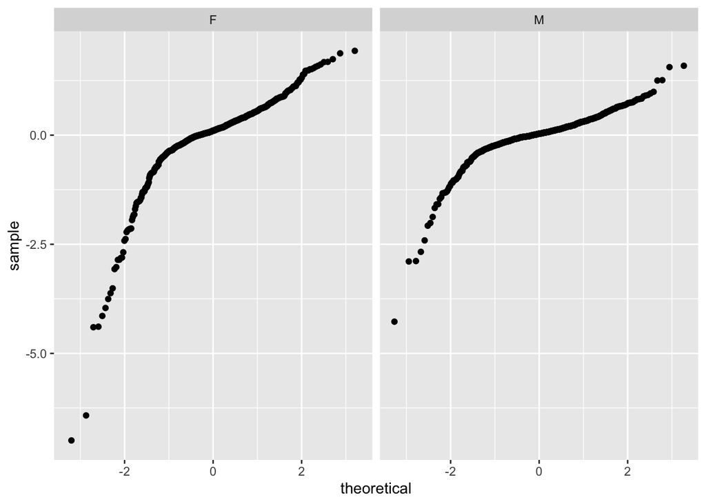

```r
diagd %>%
  ggplot(mapping = aes(sample = .resid)) +
  stat_qq() + facet_grid(~sex)
```

- Residuals vs fitted value plots.

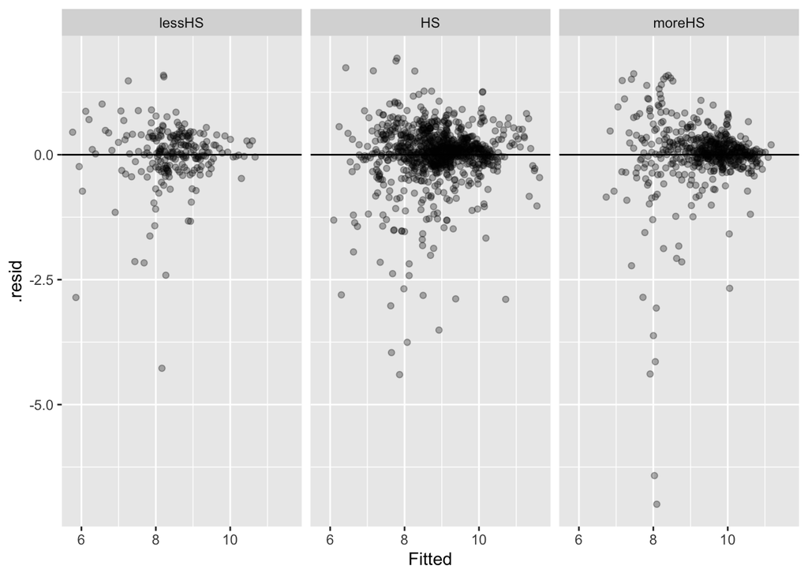

```r
diagd$edulevel <- cut(psid$educ,
                      c(0, 8.5, 12.5, 20),
                      labels=c("lessHS", "HS", "moreHS"))
diagd %>%
  ggplot(mapping = aes(x = .fitted, y = .resid)) +
  geom_point(alpha = 0.3) +
  geom_hline(yintercept = 0) +
  facet_grid(~ edulevel) +
  labs(x = "Fitted", ylab = "Residuals")
```

## 3 Repeat measures - `vision` data

- Reponse is `acuity`. Each individual is tested on left and right eyes under 4 powers.

```r
vision <- as_tibble(vision) %>%
  print(n = Inf)
```

```
# A tibble: 56 × 4
   acuity power eye   subject
    <dbl> <fct> <fct> <fct>
 1    116 6/6   left  1
 2    119 6/18  left  1
 3    116 6/36  left  1
 4    124 6/60  left  1
 5    120 6/6   right 1
 6    117 6/18  right 1
 7    114 6/36  right 1
 8    122 6/60  right 1
 9    110 6/6   left  2
10    110 6/18  left  2
11    114 6/36  left  2
12    115 6/60  left  2
```

[output cut: 44 more lines]

- Graphical summary. Individual 6 seems unsual.

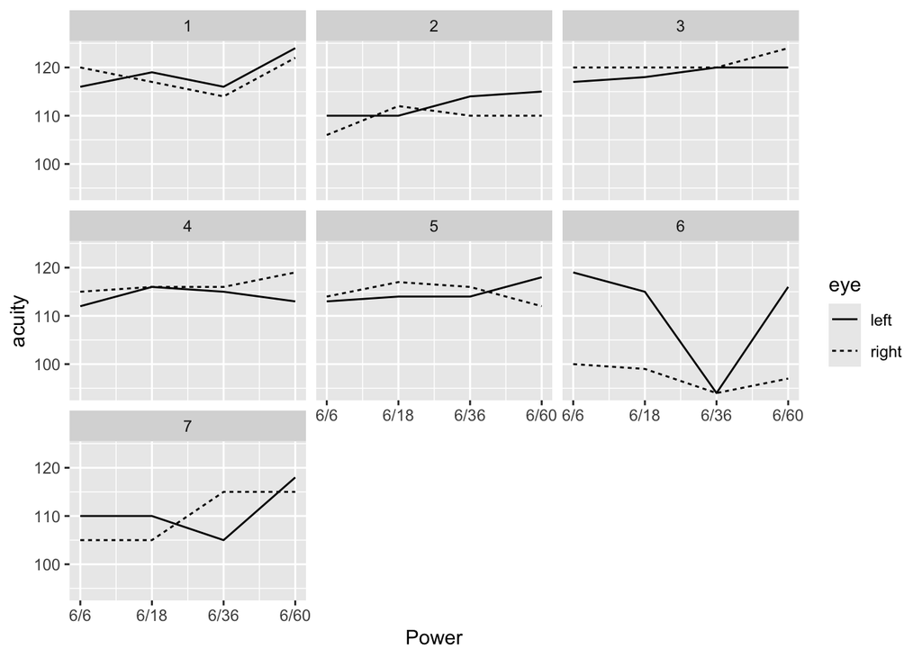

```r
vision %>%
  mutate(npower = rep(1:4, 14)) %>%
  ggplot() +
  geom_line(mapping = aes(x = npower, y = acuity, linetype = eye)) +
  facet_wrap(~ subject) +
  scale_x_continuous("Power", breaks = 1:4,
                     labels = c("6/6", "6/18", "6/36", "6/60"))
```

- Modelling: power is a fixed effect, subject is random effect, eye is nested within subjects.
  $$y_{ijk} = \mu + p_j + s_i + e_{ik} + \epsilon_{ijk},$$
  where $i=1,\ldots,7$ indexes individuals, $j=1,\ldots,4$ indexes power, and $k=1,2$ indexes eyes. The random effect distributions are
  $$s_i \sim_{\text{iid}} N(0,\sigma_s^2), \quad e_{ik} \sim_{\text{iid}} N(0,\sigma_e^2) \text{ for fixed } i, \quad \epsilon_{ijk} \sim_{\text{iid}} N(0, \sigma^2).$$
  $\sigma_e^2$ is interpreted as the variance of acuity between combinations of `eyes` and `subject`, since we don’t believe the eye difference is consistent across individuals.

```r
mmod <- lmer(acuity ~ power + (1 | subject) + (1 | subject:eye), data = vision)
summary(mmod)
```

```
Linear mixed model fit by REML ['lmerMod']
Formula: acuity ~ power + (1 | subject) + (1 | subject:eye)
   Data: vision

REML criterion at convergence: 328.7

Scaled residuals:
    Min      1Q  Median      3Q     Max
-3.4240 -0.3232  0.0109  0.4408  2.4662

Random effects:
 Groups      Name        Variance Std.Dev.
 subject:eye (Intercept) 10.27    3.205
 subject     (Intercept) 21.53    4.640
 Residual                16.60    4.075
Number of obs: 56, groups:  subject:eye, 14; subject, 7

Fixed effects:
            Estimate Std. Error t value
(Intercept) 112.6429     2.2349  50.401
power6/18     0.7857     1.5400   0.510
power6/36    -1.0000     1.5400  -0.649
power6/60     3.2857     1.5400   2.134

Correlation of Fixed Effects:
          (Intr) pw6/18 pw6/36
power6/18 -0.345
power6/36 -0.345  0.500
power6/60 -0.345  0.500  0.500
```

### 3.1 Test fixed effects

- To test the fixed effect `power`, we can use the Kenward-Roger adjusted F-test. We find the `power` is not significant at the 0.05 level.

```r
mmod <- lmer(acuity ~ power + (1 | subject) + (1 | subject:eye), data = vision, REML = TRUE)
nmod <- lmer(acuity ~ (1 | subject) + (1 | subject:eye), data = vision, REML = TRUE)
KRmodcomp(mmod, nmod)
```

```
large : acuity ~ power + (1 | subject) + (1 | subject:eye)
small : acuity ~ (1 | subject) + (1 | subject:eye)
         stat     ndf     ddf F.scaling p.value
Ftest  2.8263  3.0000 39.0000         1 0.05106 .
---
Signif. codes:  0 '***' 0.001 '**' 0.01 '*' 0.05 '.' 0.1 ' ' 1
```

- LRT

```r
mmod_mle <- lmer(acuity ~ power + (1 | subject) + (1 | subject:eye), data = vision, REML = FALSE)
nmod_mle <- lmer(acuity ~ (1 | subject) + (1 | subject:eye), data = vision, REML = FALSE)
(lrtstat <- as.numeric(2 * (logLik(mmod_mle, REML = FALSE) - logLik(nmod_mle, REML = FALSE))))
```

```
[1] 8.262412
```

```r
pchisq(lrtstat, 3, lower.tail = FALSE)
```

```
[1] 0.04088862
```

- Parametric bootstrap.

```r
library(pbkrtest)

set.seed(123)
PBmodcomp(mmod, nmod) %>%
  summary()
```

```
Bootstrap test; time: 7.41 sec; samples: 1000; extremes: 51;
large : acuity ~ power + (1 | subject) + (1 | subject:eye)
acuity ~ (1 | subject) + (1 | subject:eye)
           stat     df    ddf p.value
LRT      8.2624 3.0000        0.04089 *
PBtest   8.2624               0.05195 .
Gamma    8.2624               0.04870 *
Bartlett 7.7466 3.0000        0.05155 .
F        2.7541 3.0000 2.9092 0.21814
---
Signif. codes:  0 '***' 0.001 '**' 0.01 '*' 0.05 '.' 0.1 ' ' 1
```

- If we exclude individual 6 left eye at power 6/36, then `power` becomes significant.

```r
mmodr <- lmer(acuity ~ power + (1 | subject) + (1 | subject:eye), data = vision, REML = TRUE, subset = -43)
nmodr <- lmer(acuity ~ (1 | subject) + (1 | subject:eye), data = vision, REML = TRUE, subset = -43)
KRmodcomp(mmodr, nmodr)
```

```
large : acuity ~ power + (1 | subject) + (1 | subject:eye)
small : acuity ~ (1 | subject) + (1 | subject:eye)
         stat     ndf     ddf F.scaling p.value
Ftest  3.5956  3.0000 38.0373         1 0.02212 *
---
Signif. codes:  0 '***' 0.001 '**' 0.01 '*' 0.05 '.' 0.1 ' ' 1
```

```r
PBmodcomp(mmodr, nmodr) %>%
  summary()
```

```
Bootstrap test; time: 7.66 sec; samples: 1000; extremes: 31;
large : acuity ~ power + (1 | subject) + (1 | subject:eye)
acuity ~ (1 | subject) + (1 | subject:eye)
            stat      df    ddf p.value
LRT      10.2475  3.0000        0.01658 *
PBtest   10.2475                0.03197 *
Gamma    10.2475                0.03412 *
Bartlett  9.0967  3.0000        0.02803 *
F         3.4158  3.0000 2.8405 0.17782
---
Signif. codes:  0 '***' 0.001 '**' 0.01 '*' 0.05 '.' 0.1 ' ' 1
```

### 3.2 Test random effects

- To test significance of the variance component parameters by parametric bootstrap.

```r
mmod <- lmer(acuity ~ power + (1 | subject) + (1 | subject:eye), data = vision)
confint(mmod, method = "boot")
```

```
                    2.5 %     97.5 %
.sig01       2.026583e-06   5.569230
.sig02       2.309204e-08   8.080920
.sigma       3.147610e+00   4.995180
(Intercept)  1.086538e+02 117.166997
power6/18   -2.388635e+00   3.877868
power6/36   -4.111418e+00   1.892004
power6/60    3.254217e-01   6.605027
```

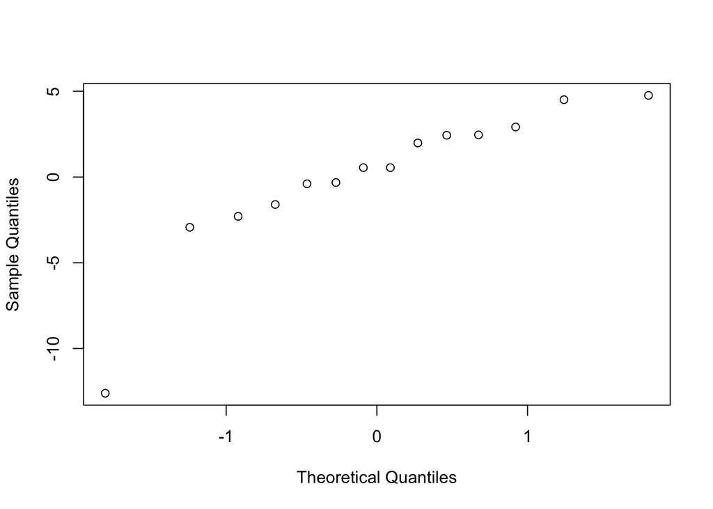

```r
qqnorm(ranef(mmodr)$"subject:eye"[[1]], main = "")
```

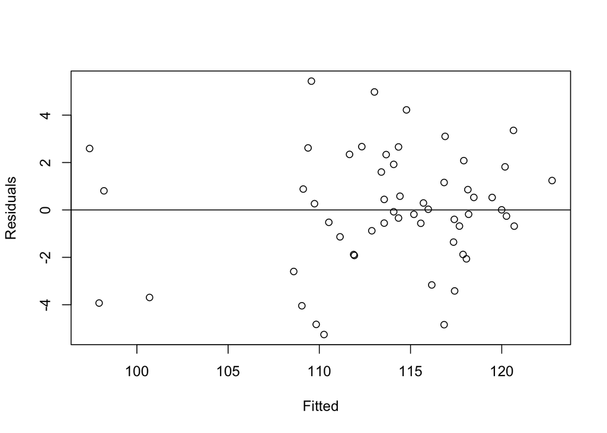

```r
plot(resid(mmodr) ~ fitted(mmodr), xlab = "Fitted", ylab = "Residuals")
abline(h=0)
```